# MTH6139 Time Series

Coursework 1: Time Series Analysis on Lithium Prices

Shyla Jadav – 231176651

Spring term 2026

# Section 1: Introduction

## 1.1 Lithium and the Clean Energy Transition

Lithium has become one of the most strategically important commodities of the 21st century. As the core material in lithium-ion batteries, it underpins the global shift to clean energy by powering electric vehicles (EVs), grid-scale storage, and consumer electronics. Major trading houses have significantly increased their lithium exposure, reflecting its growing importance in the global energy transition.

The price history reflects this transformation. For most of the 2010s, lithium traded in a narrow range. Between 2020 and 2022 prices rose dramatically as electric vehicle demand surged and supply struggled to keep up. From 2023 onwards prices fell sharply as new mines in Australia and South America began producing, leading to oversupply. This boom-and-bust cycle makes lithium prices a fascinating area for time series analysis.

## 1.2 The LIT ETF and Why I Used It

This project analyses the Global X Lithium & Battery Tech ETF (ticker: LIT), which tracks companies across the full lithium supply chain including SQM and Panasonic. Because their revenues depend directly on lithium prices and EV demand, LIT served as a good proxy for the global lithium market.

I used LIT rather than raw lithium prices as it can be fetched live from Yahoo Finance in a single line of R code, with no manual downloading or data cleaning required.

I applied Meta’s Prophet forecasting system to identify trends, detect turning points and produce a price forecast.

# Section 2: Loading and Preparing the Data

## 2.1 Loading Libraries

```r
library(quantmod)
library(prophet)
library(dplyr)
library(zoo)
```

## 2.2 Fetching LIT ETF Data from Yahoo Finance

The `getSymbols()` function, part of the `quantmod` library, fetches historical price data for Global X Lithium & Battery Tech ETF directly from Yahoo Finance.

```r
getSymbols("LIT", src = "yahoo", auto.assign = TRUE)
```

```
## [1] "LIT"
```

```r
head(LIT)
```

```
##            LIT.Open LIT.High LIT.Low LIT.Close LIT.Volume LIT.Adjusted
## 2010-07-23    31.50    32.22   31.36     32.18     232100     26.45652
## 2010-07-26    32.60    33.00   32.20     32.92      82700     27.06491
## 2010-07-27    33.50    33.50   32.64     32.78      87100     26.94981
## 2010-07-28    33.00    33.00   32.40     32.66     152650     26.85116
## 2010-07-29    33.50    33.86   33.14     33.64     125400     27.65685
## 2010-07-30    33.48    33.56   32.90     33.34      53800     27.41021
```

## 2.3 Aggregating to Monthly Frequency

I aggregated daily closing prices to monthly averages in order to make a data frame that is more appropriate for trend analysis and forecasting.

```r
LithiumMonthly <- data.frame(
  ds = index(LIT),
  y  = as.numeric(Cl(LIT))
) %>%
  mutate(MonthStart = as.Date(format(ds, "%Y-%m-01"))) %>%
  group_by(MonthStart) %>%
  summarise(y = mean(y, na.rm = TRUE)) %>%
  rename(ds = MonthStart)

head(LithiumMonthly)
```

```
## # A tibble: 6 × 2
##   ds             y
##   <date>     <dbl>
## 1 2010-07-01  32.9
## 2 2010-08-01  33.2
## 3 2010-09-01  35.8
## 4 2010-10-01  39.0
## 5 2010-11-01  40.8
## 6 2010-12-01  43.0
```

The dataset contains 189 monthly observations, from 2010-07-01 to 2026-03-01.

## 2.4 Converting to a time series

Firstly I created a `ts` object with monthly frequency. The `start` argument is set using the year and month from the earliest date in the data.

```r
LithiumTS <- ts(LithiumMonthly$y,
                start     = c(as.integer(format(min(LithiumMonthly$ds), "%Y")),
                              as.integer(format(min(LithiumMonthly$ds), "%m"))),
                frequency = 12)
start(LithiumTS)
```

```
## [1] 2010    7
```

```r
end(LithiumTS)
```

```
## [1] 2026    3
```

```r
frequency(LithiumTS)
```

```
## [1] 12
```

To access the times in the `ts` object I have used the function `time()`. This returned a time series with the dates. To convert this to a vector of dates I used the function `yearmon()` from the `zoo` library.

```r
head(as.yearmon(time(LithiumTS)))
```

```
## [1] "Jul 2010" "Aug 2010" "Sep 2010" "Oct 2010" "Nov 2010" "Dec 2010"
```

# Section 3: Analysing the Data

## 3.1 Time Series Plot

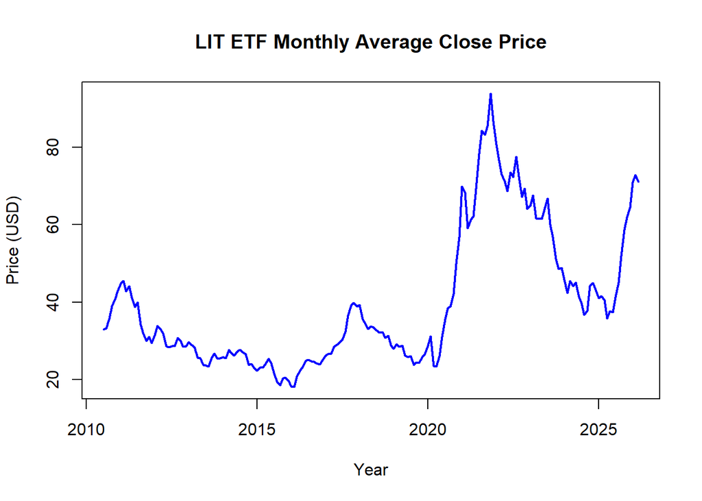

```r
plot(LithiumTS,
     main = "LIT ETF Monthly Average Close Price",
     ylab = "Price (USD)",
     xlab = "Year",
     col  = "blue",
     lwd  = 2)
```

**1) 2010–2015 (Initial Decline):** Prices started around $35 before falling to a low of around $18 by 2015 as lithium demand remained weak.

## 3.2 Multiplicative Decomposition

To separate the trend, seasonal, and residual noise components I applied multiplicative decomposition.

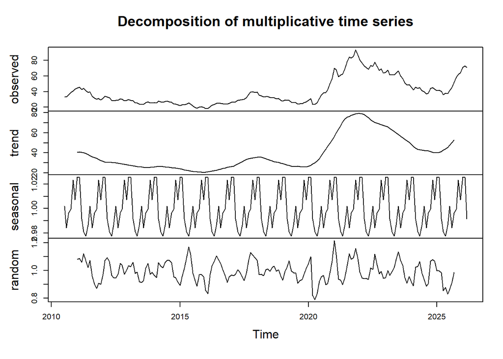

```r
LithiumDecomp <- decompose(LithiumTS, type = "multiplicative")
plot(LithiumDecomp)
```

## 3.3 Linear Trend

To quantify the average long-term growth rate I fitted a simple linear regression model:

```r
TimeIndex   <- 1:length(LithiumTS)
LinearModel <- lm(LithiumTS ~ TimeIndex)
summary(LinearModel)
```

```
##
## Call:
## lm(formula = LithiumTS ~ TimeIndex)
##
## Residuals:
##     Min      1Q  Median      3Q     Max
## -20.556 -10.883  -4.075  10.529  46.235
##
## Coefficients:
##             Estimate Std. Error t value Pr(>|t|)
## (Intercept) 21.66728    2.08823  10.376   <2e-16 ***
## TimeIndex    0.18906    0.01906   9.919   <2e-16 ***
## ---
## Signif. codes:  0 '***' 0.001 '**' 0.01 '*' 0.05 '.' 0.1 ' ' 1
##
## Residual standard error: 14.3 on 187 degrees of freedom
## Multiple R-squared:  0.3447, Adjusted R-squared:  0.3412
## F-statistic: 98.38 on 1 and 187 DF,  p-value: < 2.2e-16
```

The slope of the linear model is approximately 0.189, meaning the LIT ETF price grew by around $0.19 per month on average over the full period. However the R-squared value of 0.34 indicates the linear model only explains 34% of the variation in price, confirming that a straight line is a poor fit for this data. The dramatic 2020–2022 surge and subsequent fall are clearly non-linear and cannot be captured by a simple linear trend alone, which is why Prophet is better suited for this series.

## 3.4 Log Transformation

As previously mentioned, the LIT ETF closing prices show much larger fluctuations during the 2021–2022 spike than in earlier periods, suggesting the variance is not constant over time. Hence heteroskedasticity is present.

Taking the natural log can help stabilise this variance and make the data easier to model.

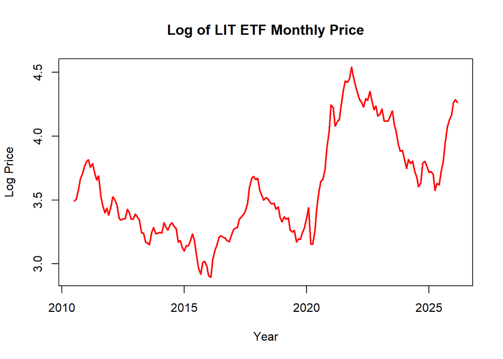

```r
LithiumLogTS <- log(LithiumTS)

plot(LithiumLogTS,
     main = "Log of LIT ETF Monthly Price",
     ylab = "Log Price",
     xlab = "Year",
     col  = "red",
     lwd  = 2)
```

Comparing the log-transformed plot to the original found in section 3.1, the 2021–2022 spike appears less extreme on the log scale. In the original plot prices surged from around $25 to $90, whereas on the log scale this corresponds to a move from approximately 3.2 to 4.5. This is a much smaller jump suggesting that the log transformation has partially stabilised the variance.

# Section 4: Forecasting with Meta’s Prophet

## 4.1 What is Prophet?

Prophet is a forecasting library developed by Meta. It fits an additive model combining trend, seasonality, holidays and random noise:

$$y(t) = g(t) + s(t) + h(t) +
\epsilon_t$$
I fitted Prophet to the `LithiumMonthly` dataframe, which contains the `ds` (date) and `y` (price) columns required by the model.

```r
ProphetModel <- prophet(LithiumMonthly)
```

## 4.2 Creating Future Dates

```r
FutureDates <- make_future_dataframe(ProphetModel,
                                     periods = 24,
                                     freq    = "month")
tail(FutureDates)
```

```
##             ds
## 208 2027-10-01
## 209 2027-11-01
## 210 2027-12-01
## 211 2028-01-01
## 212 2028-02-01
## 213 2028-03-01
```

I created 24 months (2 years) of future dates beyond the last observation, as forecasting further ahead on this volatile time series would produce unreliable results.

## 4.3 Generating the Forecast

```r
ProphetForecast <- predict(ProphetModel, FutureDates)
tail(ProphetForecast[c("ds", "yhat", "yhat_lower", "yhat_upper")])
```

```
##             ds     yhat yhat_lower yhat_upper
## 208 2027-10-01 66.40467   49.40214   84.14074
## 209 2027-11-01 68.24049   50.40507   86.75966
## 210 2027-12-01 67.59750   51.38121   84.21661
## 211 2028-01-01 67.76916   50.82623   84.79559
## 212 2028-02-01 67.11164   49.32864   84.30963
## 213 2028-03-01 65.14184   46.66521   81.30011
```

The columns `yhat_lower` and `yhat_upper` give the uncertainty interval around the central forecast `yhat`. By default Prophet uses an 80% uncertainty interval.

## 4.4 Forecast Plot

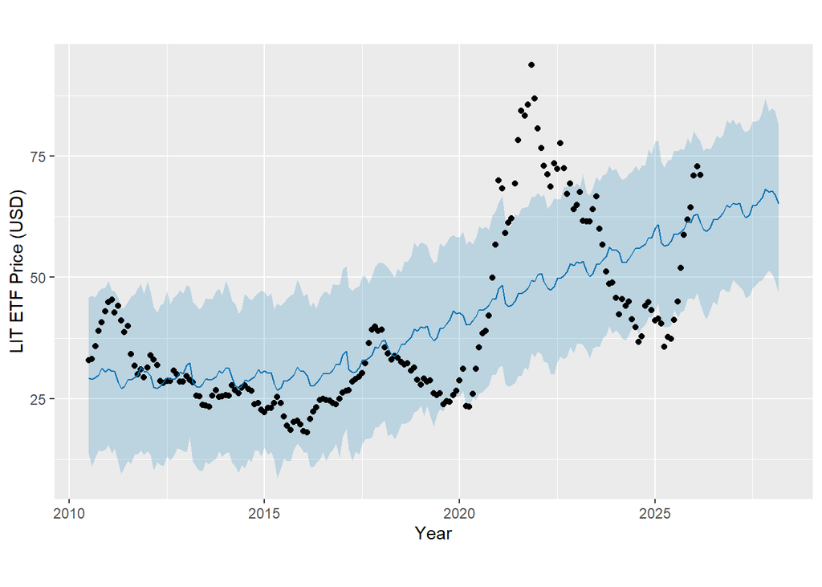

```r
plot(ProphetModel, ProphetForecast,
     xlabel = "Year",
     ylabel = "LIT ETF Price (USD)")
```

## 4.5 Forecast Components

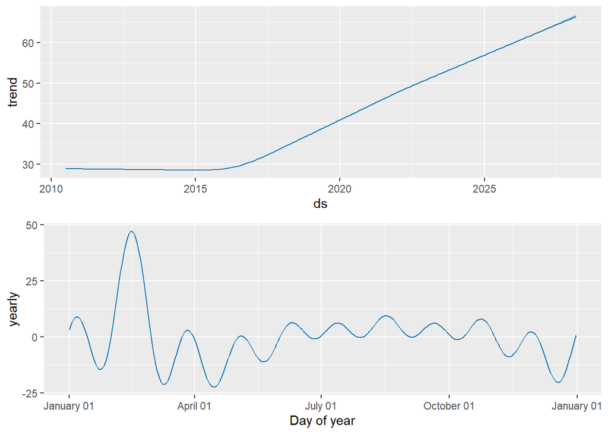

```r
prophet_plot_components(ProphetModel, ProphetForecast)
```

# Section 5: Alternative Model Without Seasonality

## 5.1 Reasoning

While some mild seasonal patterns exist in lithium prices, the dominant driver is supply and demand trends. To test whether seasonality genuinely improves the forecast, I fitted a second Prophet model without seasonality.

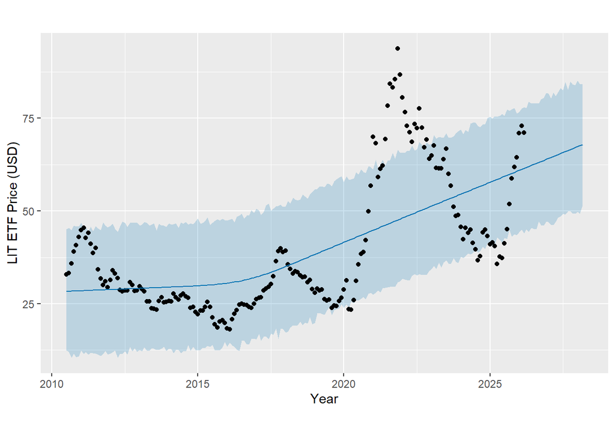

```r
ProphetModelNoSeason <- prophet(LithiumMonthly,
                                 yearly.seasonality = FALSE,
                                 weekly.seasonality = FALSE,
                                 daily.seasonality  = FALSE)

FutureDatesNoSeason <- make_future_dataframe(ProphetModelNoSeason,
                                                  periods = 24,
                                                  freq    = "month")
ProphetForecastNoSeason <- predict(ProphetModelNoSeason,
                                    FutureDatesNoSeason)
plot(ProphetModelNoSeason, ProphetForecastNoSeason,
     xlabel = "Year",
     ylabel = "LIT ETF Price (USD)")
```

Without seasonality, the model produces a much smoother forecast, capturing only the underlying upward trend. Compared to the original model in Section 4.5, the fitted line no longer follows the short-term fluctuations in the historical data.

## 5.2 Comparing the Two Forecasts

```r
ForecastComparison <- data.frame(
  Date            = tail(ProphetForecast$ds, 6),
  WithSeasonality = round(tail(ProphetForecast$yhat, 6), 2),
  NoSeasonality   = round(tail(ProphetForecastNoSeason$yhat, 6), 2)
)
ForecastComparison
```

```
##         Date WithSeasonality NoSeasonality
## 1 2027-10-01           66.40         66.54
## 2 2027-11-01           68.24         66.81
## 3 2027-12-01           67.60         67.07
## 4 2028-01-01           67.77         67.35
## 5 2028-02-01           67.11         67.62
## 6 2028-03-01           65.14         67.87
```

The two forecasts are very similar, with values differing by no more than $2–3 across all six periods. This suggests that seasonality has a minimal impact on the overall forecast, and that the trend is the dominant driver of LIT ETF prices. This is consistent with the idea of lithium being a commodity shaped primarily by supply and demand cycles rather than seasonal patterns.

# Section 6: Conclusions

Prophet forecast a gradual upward trend in LIT ETF prices over the next two years, reaching approximately $65 by early 2028. However the wide uncertainty interval highlights the difficulty of forecasting a volatile commodity time series with confidence. Comparing models with and without seasonality produced very similar results, confirming that supply and demand trends are the dominant driver of lithium prices rather than seasonal patterns.

While Prophet is a powerful forecasting tool, it cannot anticipate future events such as policy changes or geopolitical disruptions. Forecast should therefore be treated as a general indication of direction rather than a precise prediction.

# References

- Global X LIT ETF: https://www.globalxetfs.com/funds/lit/
- quantmod R package: https://www.quantmod.com/
- Meta Prophet Documentation: https://facebook.github.io/prophet/docs/quick_start.html#r-api
- Prophet R package: https://cran.r-project.org/package=prophet